# R Notebook

```r
library(tidyverse)
```

| X | estimated_length | actual_length |
| --- | --- | --- |
| 1 | 12 | 17 |
| 2 | 16 | 22 |
| 3 | 16 | 23 |
| 4 | 18 | 25 |
| 5 | 22 | 39 |
| 6 | 19 | 24 |
| 7 | 18 | 24 |
| 8 | 18 | 21 |
| 9 | 18 | 23 |
| 10 | 15 | 20 |

[output cut: 40 more lines]

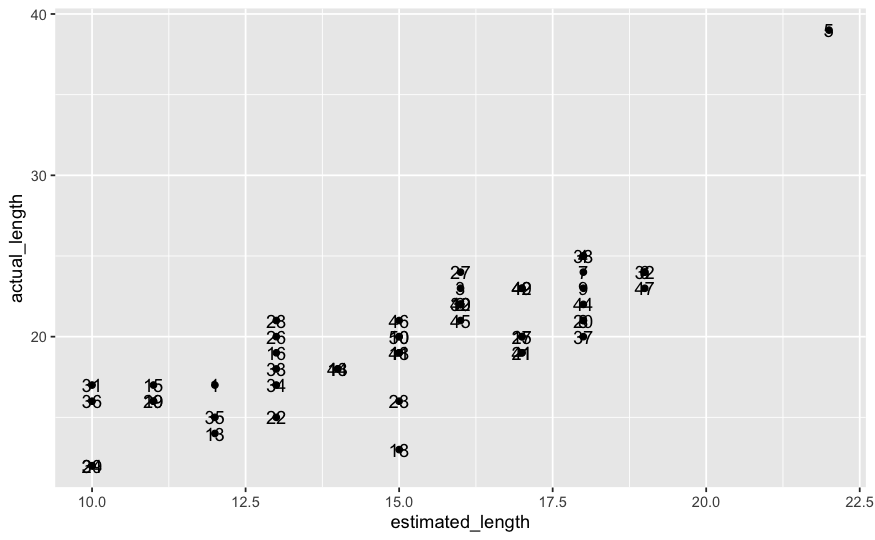

```r
proj_management %>%
  ggplot() +
  aes(x = estimated_length, y = actual_length, label = 1:nrow(proj_management)) +
  geom_point() +
  geom_text()
```

```r
NA
NA
NA
```

There is a number of possible outliers (24, 18, tops of the groups at (x = 13, 16, 18)) - the obvious one in this case is ‘5’, which is way above the general trend of values; this is an influential outlier.

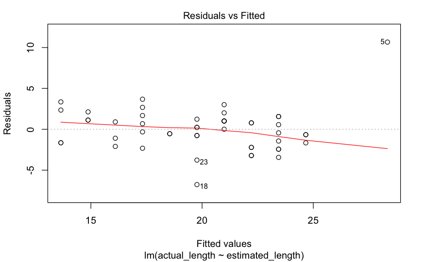

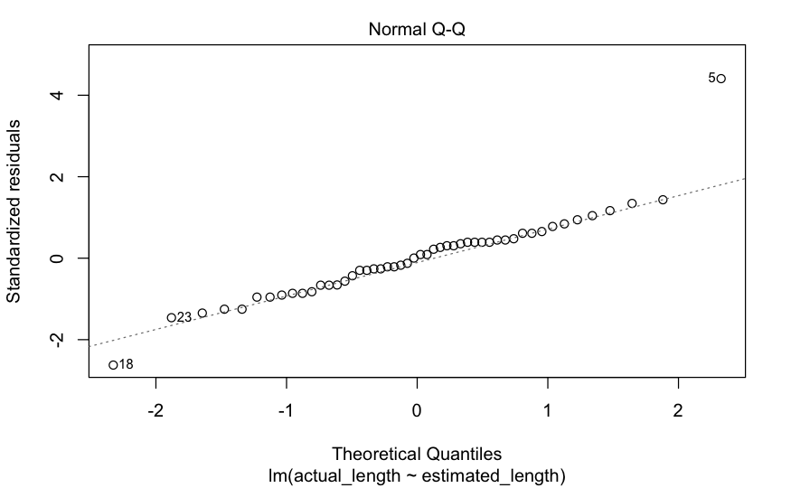

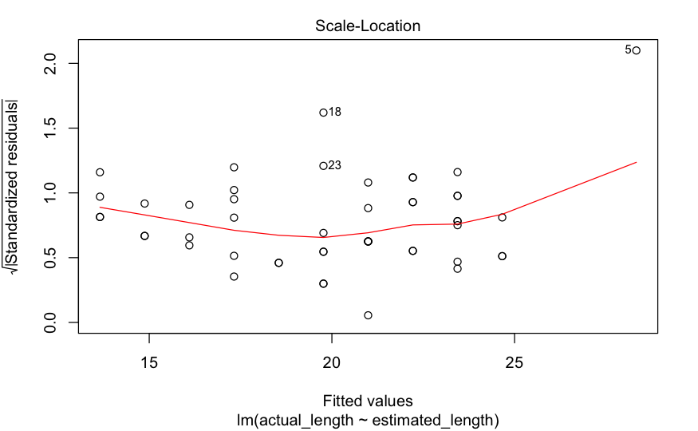

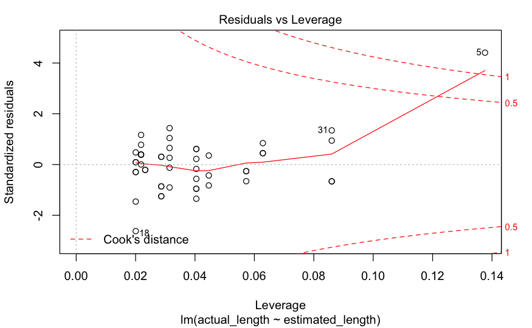

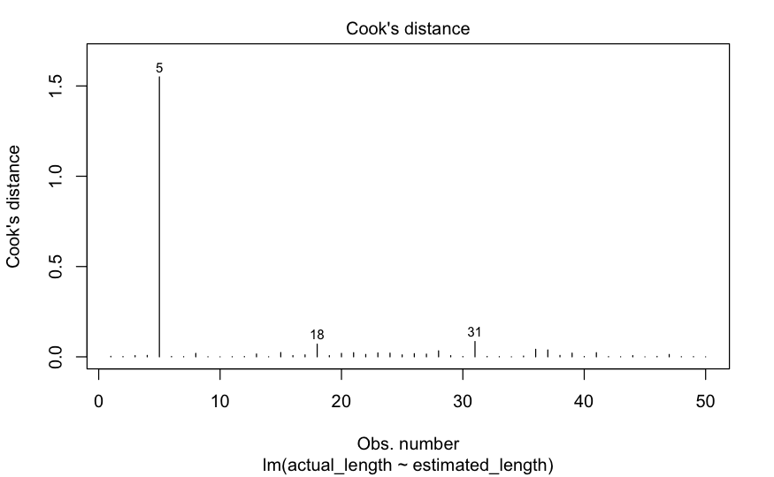

Clearly the 5th value is outside Cook’s Distance in the initial Residuals vs Leverage plot, furthermore when we observe a plot of Cook’s distance values and see 5 as our main contributor.

Now let’s remove the outlier, before that though let’s just see what the changes are when we remove on of the smaller outliers we identified.

```r
lm(proj_management$actual_length ~ proj_management$estimated_length)
```

```
Call:
lm(formula = proj_management$actual_length ~ proj_management$estimated_length)

Coefficients:
                     (Intercept)  proj_management$estimated_length
                           1.416                             1.223
```

```r
lm(new_proj_management$actual_length ~ new_proj_management$estimated_length)
```

```
Call:
lm(formula = new_proj_management$actual_length ~ new_proj_management$estimated_length)

Coefficients:
                         (Intercept)  new_proj_management$estimated_length
                               1.591                                 1.221
```

A small change from the intercept before removing the outlier, but not an insignificant one.

This will likely not change much about the fitting.

```r
new_proj_management %>%
  ggplot() +
  aes(x = estimated_length, y = actual_length) +
  geom_point()
```

[output not shown]

```r
plot(lm(new_proj_management$actual_length ~ new_proj_management$estimated_length))
```

[output not shown]

```r
plot(lm(proj_management$actual_length ~ proj_management$estimated_length))
```

[output not shown]

Let’s try with the influential outlier in row 5

|  | X | estimated_length | actual_length |
| --- | --- | --- | --- |
| 1 | 1 | 12 | 17 |
| 2 | 2 | 16 | 22 |
| 3 | 3 | 16 | 23 |
| 4 | 4 | 18 | 25 |
| 6 | 6 | 19 | 24 |
| 7 | 7 | 18 | 24 |
| 8 | 8 | 18 | 21 |
| 9 | 9 | 18 | 23 |
| 10 | 10 | 15 | 20 |
| 11 | 11 | 15 | 19 |

[output cut: 39 more lines]

```r
lm(new_proj_management$actual_length ~ new_proj_management$estimated_length)
```

```
Call:
lm(formula = new_proj_management$actual_length ~ new_proj_management$estimated_length)

Coefficients:
                         (Intercept)  new_proj_management$estimated_length
                               4.381                                 1.011
```

A huge change in intercept value.

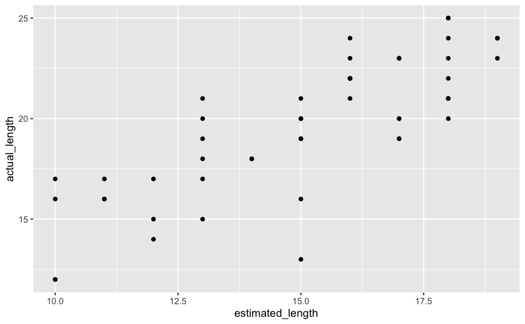

```r
new_proj_management %>%
  ggplot() +
  aes(x = estimated_length, y = actual_length) +
  geom_point()
```

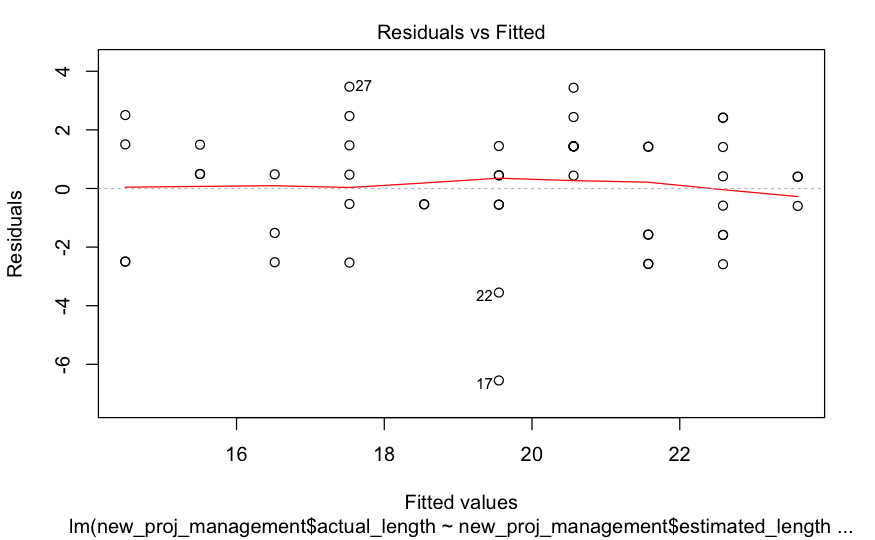

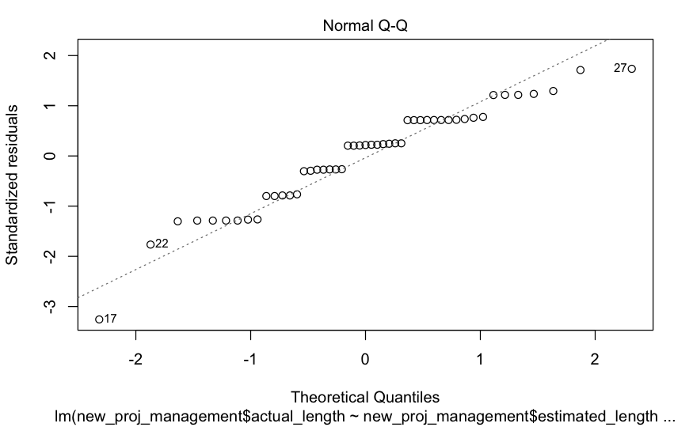

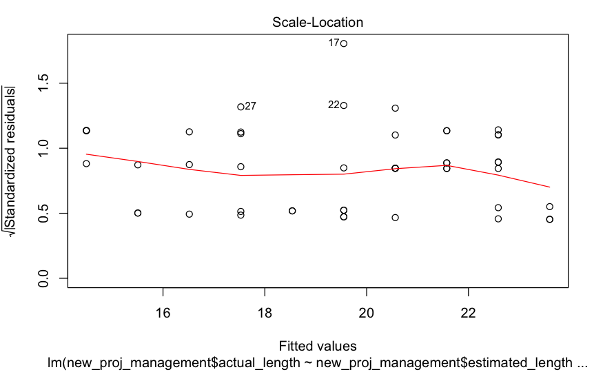

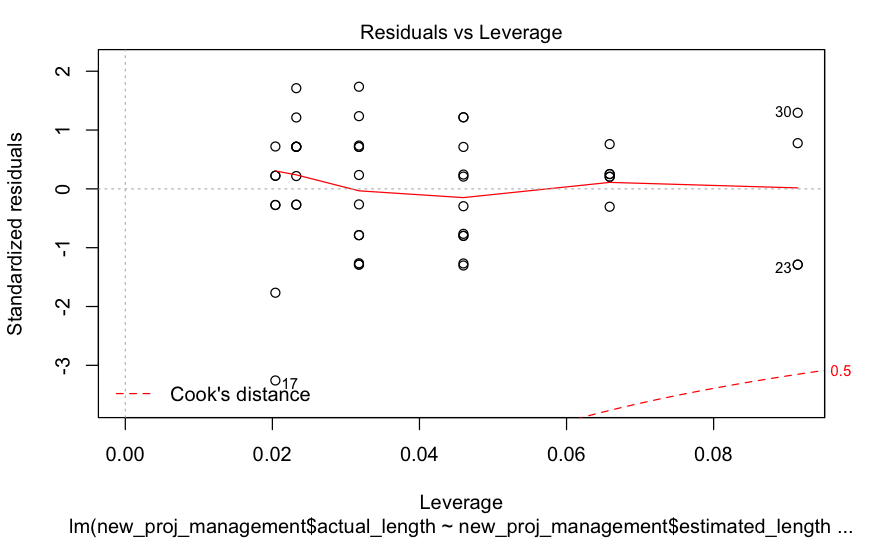

```r
plot(lm(new_proj_management$actual_length ~ new_proj_management$estimated_length))
```

```r
NA
NA
NA
```

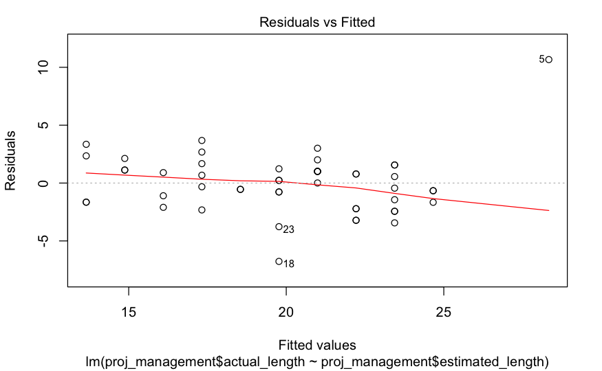

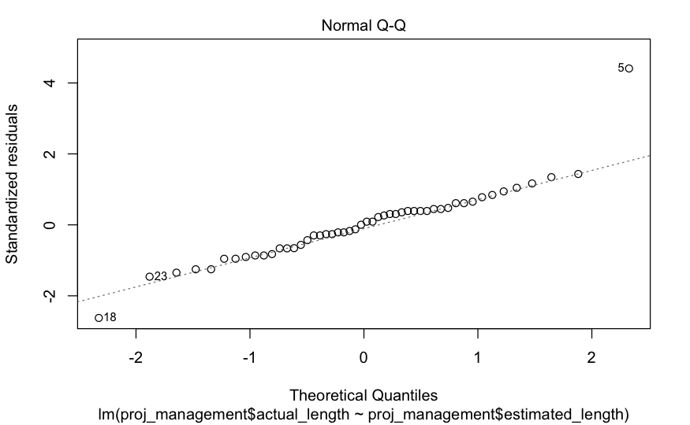

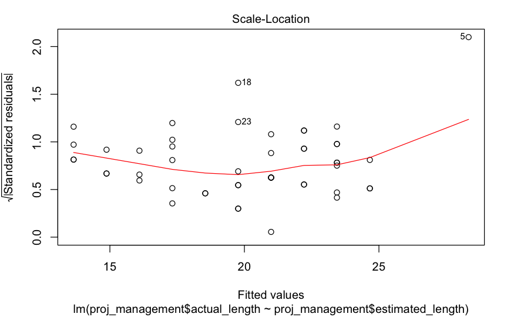

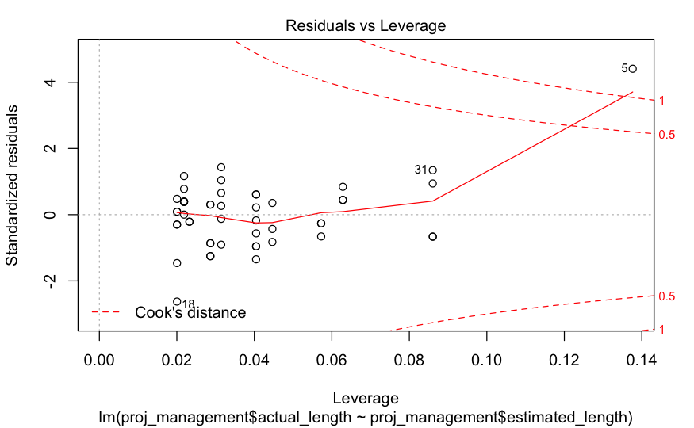

```r
plot(lm(proj_management$actual_length ~ proj_management$estimated_length))
```

```r
NA
NA
```

In the new dataset with the influential outlier omitted we can see the lines differ hugely, with the new regression keep a rather steady Reg. vs Lev. line.

[figure not shown]

[figure not shown]

[figure not shown]

[figure not shown]